# Vis Creative Assignment 2

```r
#Africa
MERC <- "+proj=tmerc +lat_0=0 +lon_0=31 +k=1 +x_0=0 +y_0=0 +ellps=WGS84 +units=m +no_defs"
SA <- "+proj=aea +lat_1=-2 +lat_2=-22 +lat_0=-12 +lon_0=-54 +x_0=0 +y_0=0 +ellps=aust_SA +units=m +no_defs "
POLE <- "+proj=laea +lat_0=90 +lon_0=-100 +x_0=0 +y_0=0 +ellps=WGS84 +datum=WGS84 +units=m +no_defs"
```

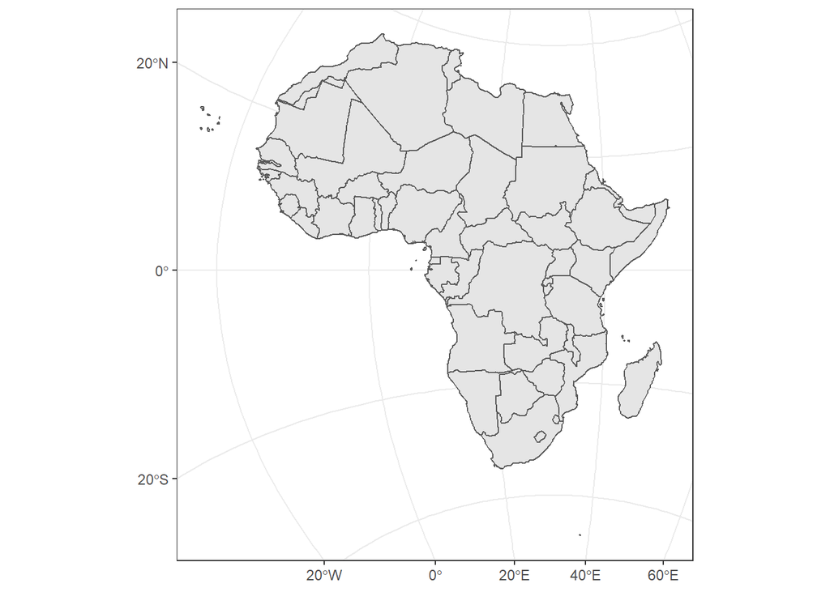

```r
#Africa <- world %>%
  #filter(continent == "Africa")

ggplot(Africa) +
  geom_sf() +
  coord_sf(crs = MERC) +
  theme_bw()
```

## Africa Map (Projection 2 - Albers Conical Equal Area, South America)

Here is Africa mapped on a projection that it usually used for South America.

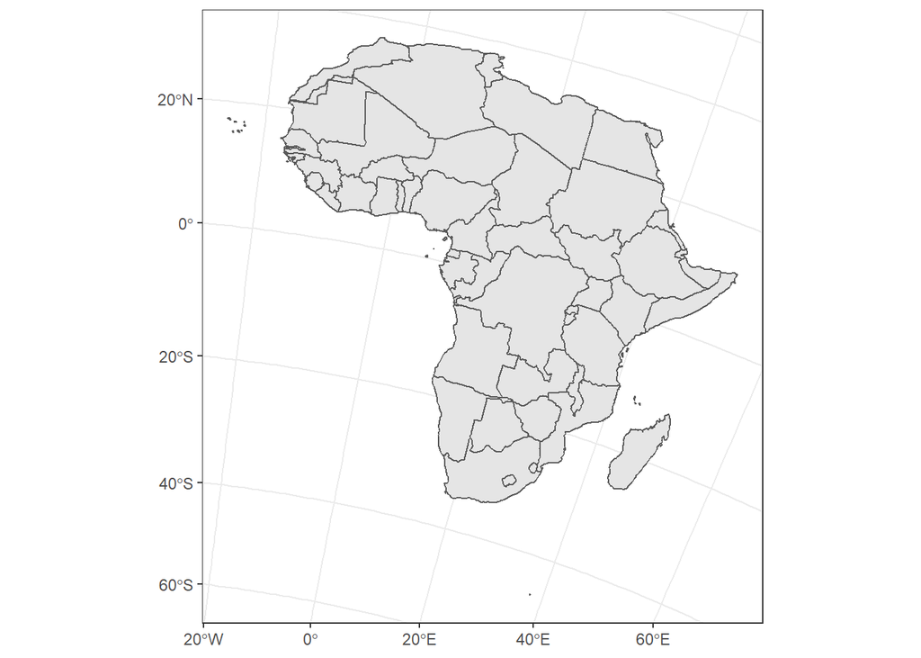

```r
#Africa <- world %>%
  #filter(continent == "Africa")

ggplot(Africa) +
  geom_sf() +
  coord_sf(crs = SA) +
  theme_bw()
```

## Africa Map (Projection 3 - WGS 84 / North Pole LAEA Atlantic)

I think my favorite is the North Pole projection. It’s a much different perspective than I’m used to seeing.

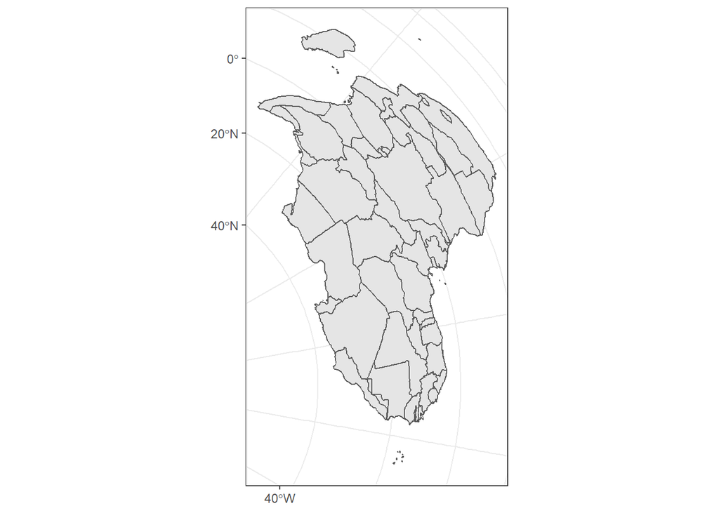

```r
#Africa <- world %>%
  #filter(continent == "Africa")

ggplot(Africa) +
  geom_sf() +
  coord_sf(crs = POLE) +
  theme_bw()
```

## Mapping COVID Cases in Africa by Country

I will now map the number of COVID cases in Africa by country as of September 20th, using data I obtained from the website Trading Economics. I have saved the data as a CSV file and will attempt to map confirmed COVID cases by country.

Below, I have mapped the confirmed COVID cases in Africa by country, as well as in continuous cartogram, non-continuous cartogram, and proportional symbol map form. These cartograms really demonstrate the severity of the pandemic in South Africa compared to the rest of the continent. Please note, however, that this dataset does not include data for some countries whose case reporting may have been considered to be unreliable.

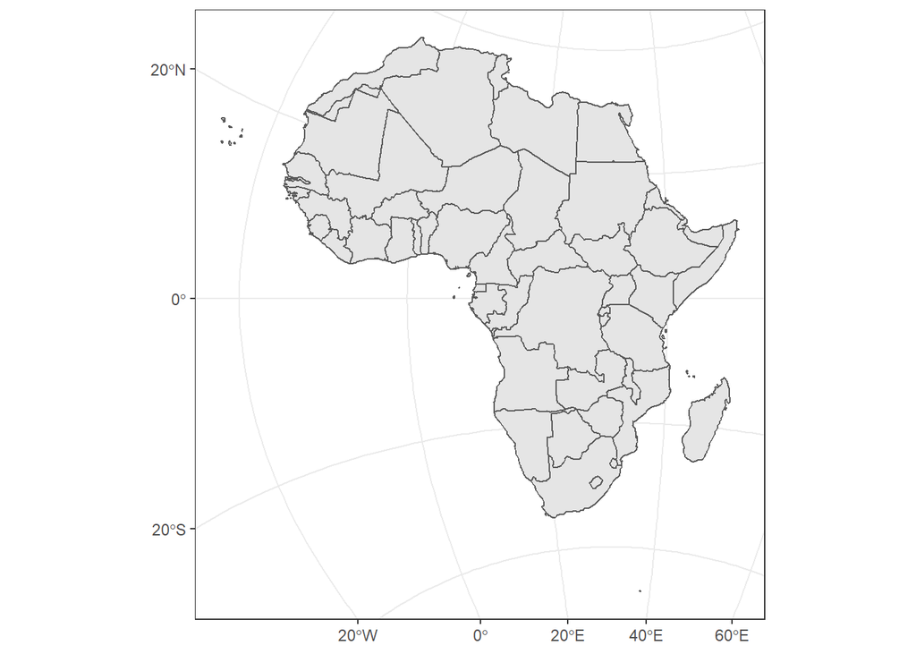

```r
africa_transformed <- Africa %>%
  st_transform(crs = MERC)

ggplot(africa_transformed) +
  geom_sf() +
  theme_bw()
```

```r
covid_africa <- read_csv("africa_covid_cases_sep20.csv")

covid_africa_countries <-africa_transformed %>%
  left_join(covid_africa, by = c("name" = "Country")) %>%
  select(name, "Last", "Previous",  "Reference",    "Unit")
```

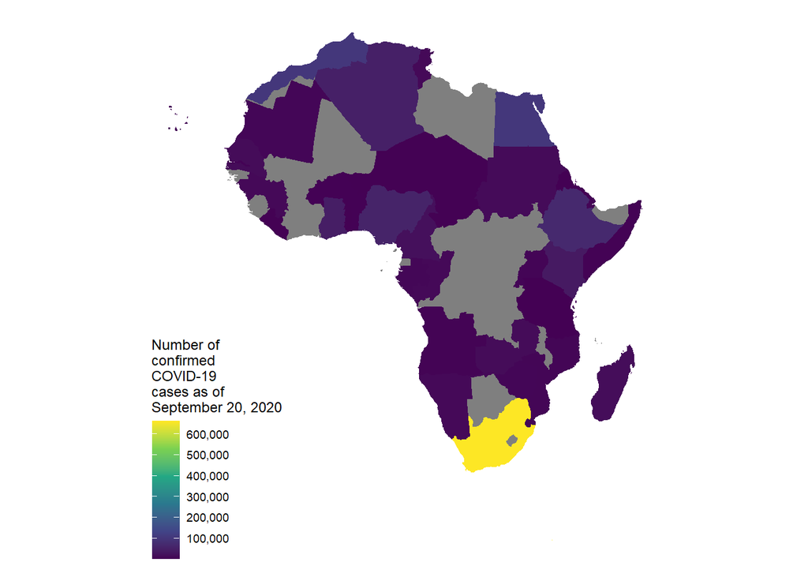

```r
ggplot(covid_africa_countries, aes(fill = Last)) +
  geom_sf(color = NA) +
  scale_fill_viridis_c(
    name = "Number of\nconfirmed\nCOVID-19\ncases as of\nSeptember 20, 2020",
    breaks = seq(0, 670000, by = 100000),
    labels = formatC(seq(0, 670000, by = 100000),
                     big.mark = ",", format = "f", digits = 0)) +
  theme_map() +
  theme(legend.background = element_blank())
```

```r
covid_cartogram_cont <- covid_africa_countries %>%
  cartogram_cont("Last")
```

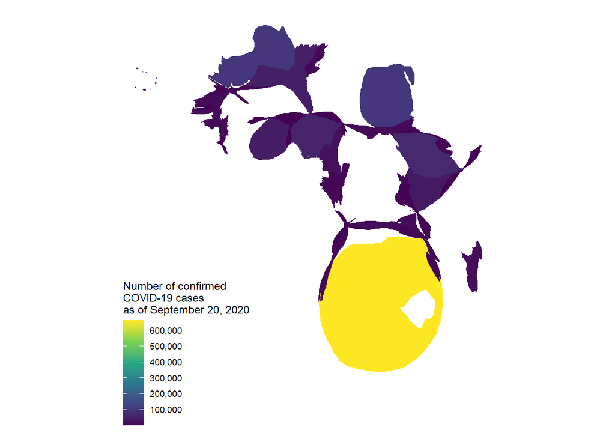

```r
ggplot(covid_cartogram_cont, aes(fill = Last)) +
  geom_sf(color = NA) +
  scale_fill_viridis_c(
    name = "Number of confirmed\nCOVID-19 cases\nas of September 20, 2020",
    breaks = seq(0, 670000, by = 100000),
    labels = formatC(seq(0, 670000, by = 100000),
                     big.mark = ",", format = "f", digits = 0)) +
  theme_map() +
  theme(legend.background = element_blank())
```

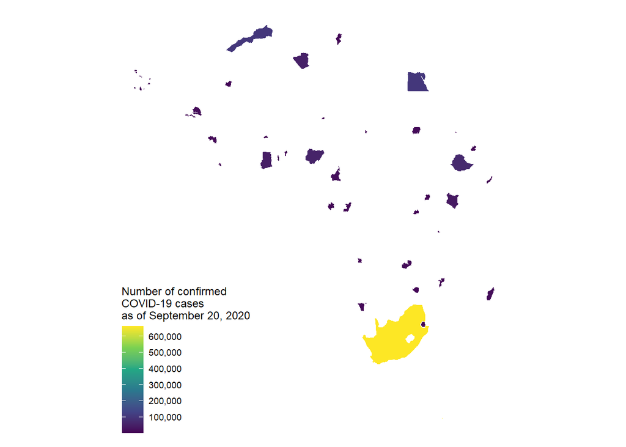

```r
covid_cartogram_ncont <- covid_africa_countries %>%
  cartogram_ncont("Last")

ggplot(covid_cartogram_ncont, aes(fill = Last)) +
  geom_sf(color = NA) +
  scale_fill_viridis_c(
    name = "Number of confirmed\nCOVID-19 cases\nas of September 20, 2020",
    breaks = seq(0, 670000, by = 100000),
    labels = formatC(seq(0, 670000, by = 100000),
                     big.mark = ",", format = "f", digits = 0)) +
  theme_map() +
  theme(legend.background = element_blank())
```

```r
covid_centeroids <- covid_africa_countries %>%
  st_centroid()
```

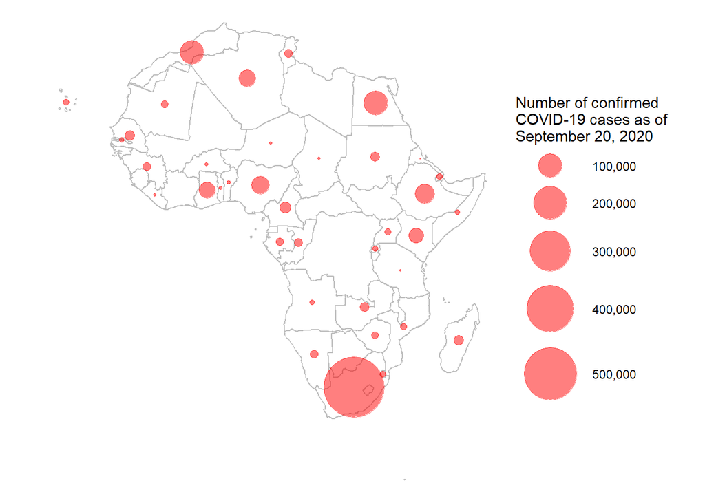

```r
ggplot(africa_transformed) +
  geom_sf(fill = NA, color = "gray") +
  geom_sf(data = covid_centeroids,
          aes(size = Last),
          alpha = 0.5, color = "red") +
  scale_size_continuous(name = "Number of confirmed\nCOVID-19 cases as of\nSeptember 20, 2020",
    breaks = seq(100000, 500000, by = 100000),
    labels = formatC(seq(100000, 500000, by = 100000),
                     big.mark = ",", format = "f", digits = 0),
    range = c(0, 20)) +
  theme_void()
```